# Anderson Rocha - Análise da Produção e Consumo de Petróleo

```
## [1] "character"
```

```
## [1] "character"
```

# Seção de Gráficos Univariados

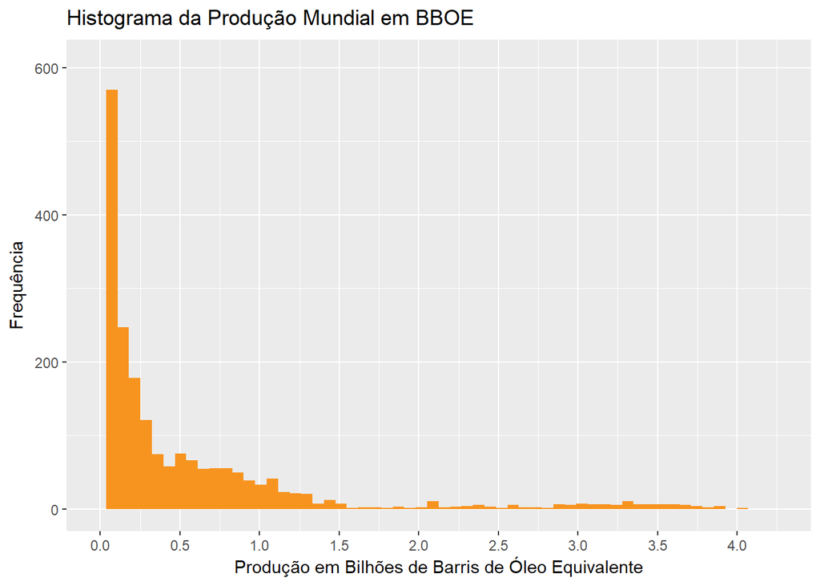

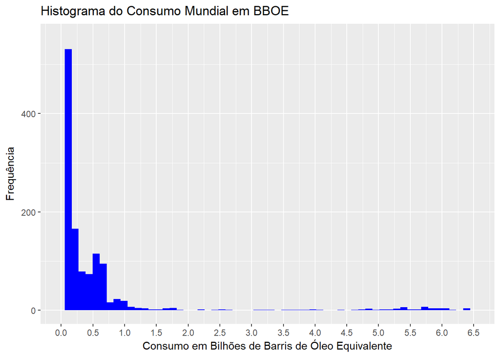

# Análise Univariada

### Qual é a estrutura do conjunto de dados?

Os dados foram obtidos da gapminder, subgrupos energy / oil (https://www.gapminder.org/data/). Foram utilizados 2 DATASETS, um sobre a produção de petróleo e outro sobre o consumo, esses DATASETS foram formatados para facilitar a análise dos dados de forma temporal, e posteriormente mesclados, o formato final ficou com 2548 linhas e 4 colunas, que representam: País, ano, produção e consumo, que estão expressos em BBOE (barrels of oil equivalent).

Também foi criada a coluna ‘Opep’ para identificar quais são os países que fazem parte da **OPEP** (organização dos países produtores de petróleo), dessa forma o DATASET final ficou com 2548 linhas e 5 colunas.

### Quais são os principais atributos de interesse deste conjunto de dados?

Os atributos mais importantes são a **Produção** e o **Consumo**.

### Quais outros atributos você acha que podem lhe auxiliar na investigação destes atributos de interesse?

Os demais atributos, **País** e **Ano**, são igualmente importantes pois nos permite comparar a produção e o Consumo entre os países e também o desempenho ao longo do tempo, identificando ocorrências que influenciaram por exemplo a produção.

### Você criou novas variáveis a partir dos atributos existentes no conjunto de dados?

As variáveis Produção e Consumo foram recalculadas, no DATASET original as mesmas estavam na unidade TOE (Tons Of Oil Equivalent) que não é a unidade de praxe para acompanhamento da produção e consumo de petroléo na indústria, a mesma foi recalculada para BBOE (Barrels Of Oil Equivalent).

Também foi transformada a variável ano, onde existia uma variável para cada ano.

E por último foi criada a variável ‘Opep’ como descrito anteriormente.

### Dos atributos investigados, distribuições incomuns foram encontradas? Você aplicou operações nos dados para limpá-los, ajustá-los ou mudar a forma dos dados? Se sim, por quê?

A distribuição é altamente enviesada, porém, isso reflete a realidade, ou seja, a grande maioria das produções anuais dos países não passa de 1 bilhão de barris, percebe-se que poucas produções anuais se concentram em 1.5 e 4.0 bilhões no ano.

Em relação ao consumo a tendência se repete, a maioria das ocorrências de consumo se concentram em países que consomem até 600 milhões BOE no ano, poucos são os grandes consumidores de Petróleo que exploraremos mais a diante.

# Seção de Gráficos Bivariados

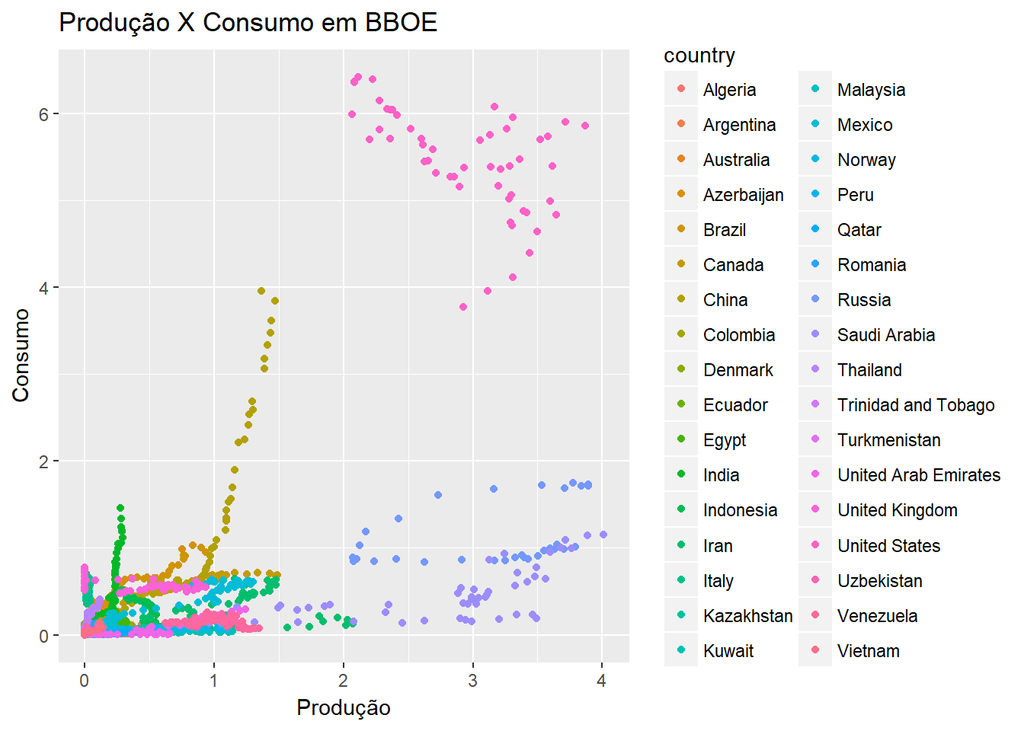

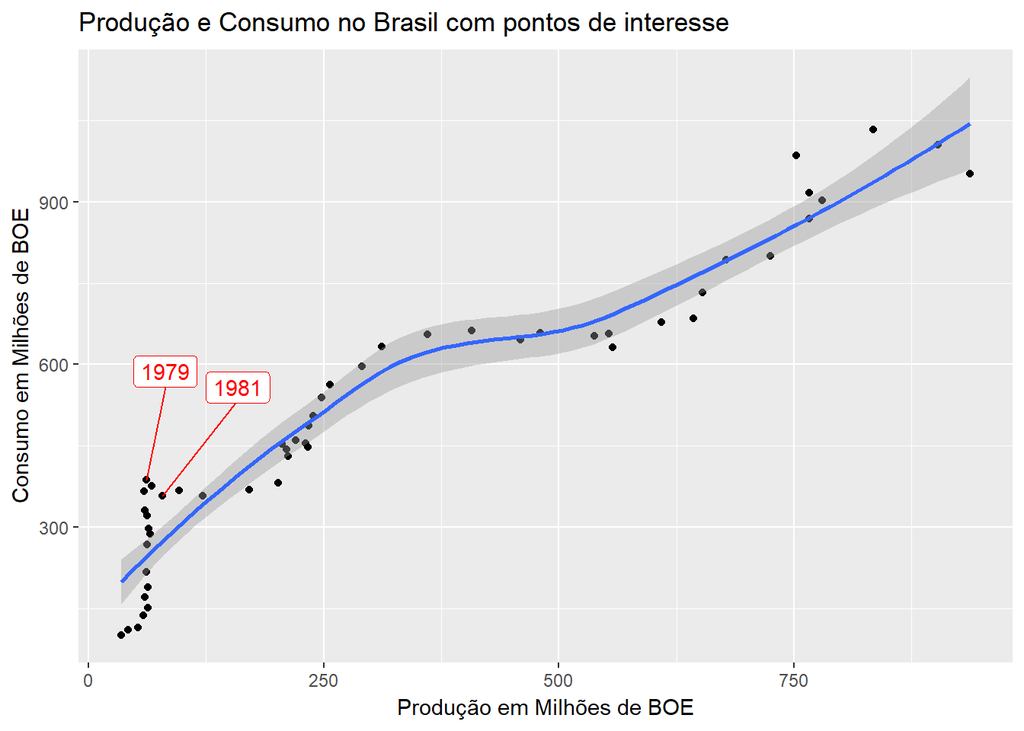

```
##      cor
## 63.44243
```

# Análise Bivariada

### Discuta sobre alguns dos relacionamentos observados nesta parte da investigação. Como os atributos de interesse variaram no conjunto de dados?

Foram considerados os atributos Produção e Consumo na análise Bivariada, dois gráficos foram criados e seguem as considerações sobre cada um deles:

- **Gráfico (PRODUÇÃO X CONSUMO):**

  Esse gráfico explorou a relação Produção x Consumo de todos os países do DATASET, existem alguns destaques nítidos: Existem 4 grandes clusteres de dados:
  1. Estados Unidos, com uma elavada taxa de produção e consumo, porém é nítido que a demanda é maior que a produção;
  2. Russia e Arábia Saudita, tem produção elevada destacada, nesse caso eles produzem mais do que consomem;
  3. China, é muito visível o crescimento do consumo Chinês, porém a produção não + acompanha a demanda, o que faz da China um dos maiores importadores líquidos do mundo;
  4. O maior cluster são dos países que têm equilíbrio entre consumo e produção.
- **Gráfico (PRODUÇÃO E CONSUMO NO BRASIL, COM PONTOS DE DESTAQUES):**

  Se não fosse a produção estagnada até o ano de 1979, seria possível afirmar que a relação Produção x Consumo no Brasil é quase linear, ou seja, a Produção acompanhando a demanda, após o ano de 1981 a Produção cresce sucessivamente.

### Você observou algum relacionamento interessante entre os outros atributos (os que não são de interesse)?

A produção e consumo, estão relacionados diretamente com o ano, fatores geopolíticos por exemplo, influenciam a Produção e a Demanda, mais a frente ficará claro essa evolução através da inserção da variável tempo (anos).

### Qual foi o relacionamento mais forte encontrado?

Prodção e Consumo, apresentam uma relação moderada de **63.44%**

# Seção de Gráficos Multivariados

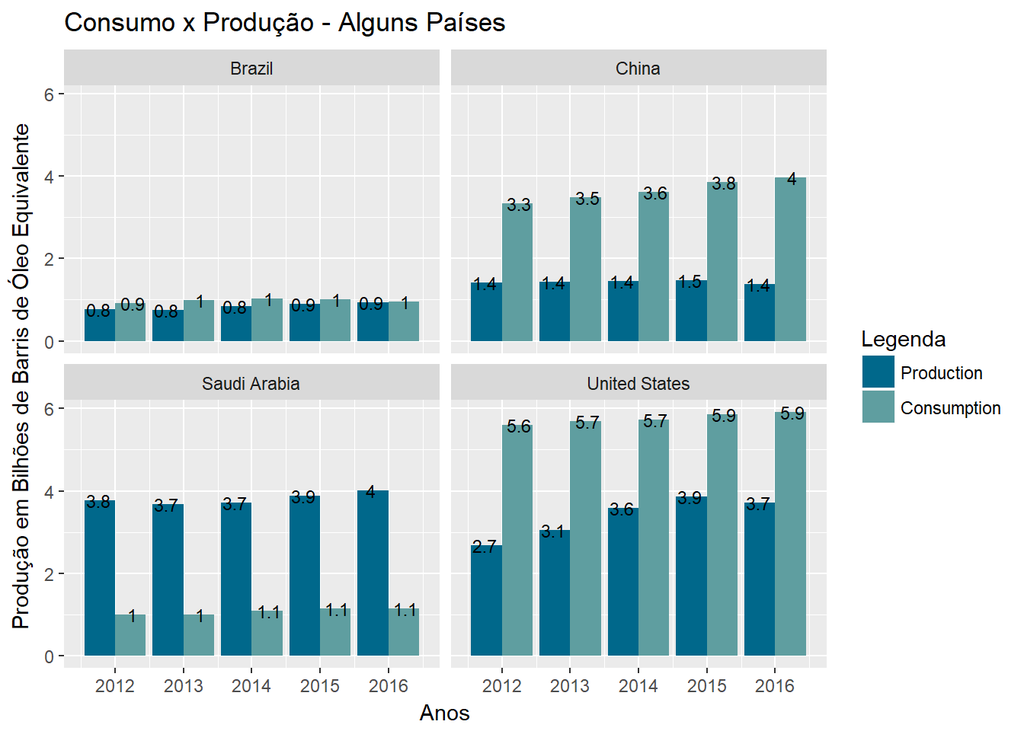

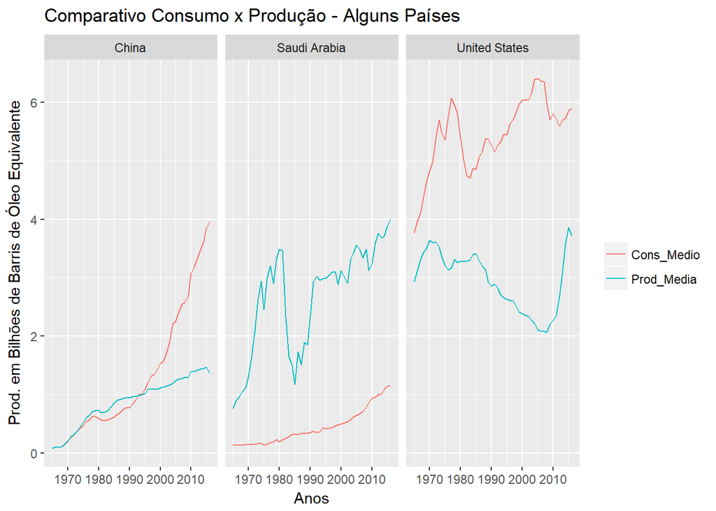

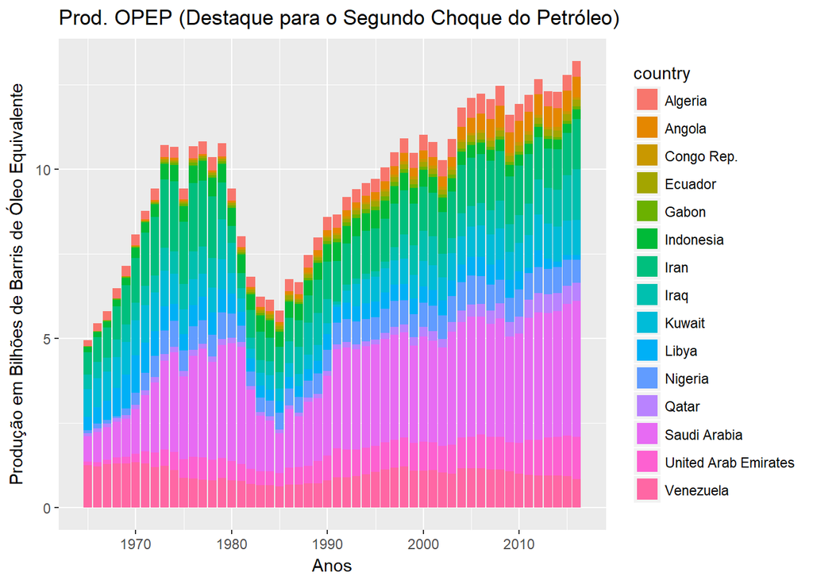

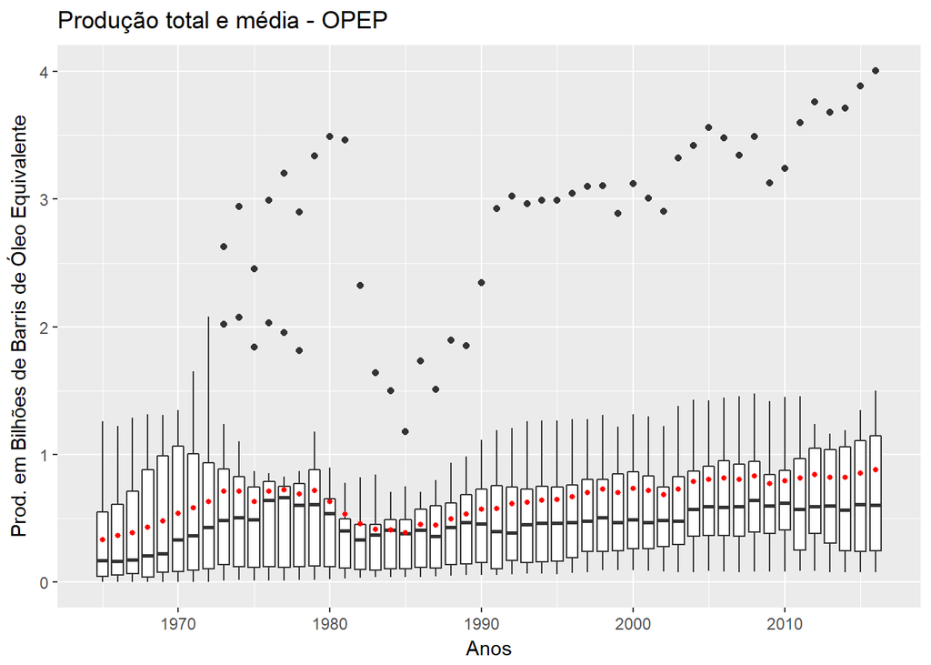

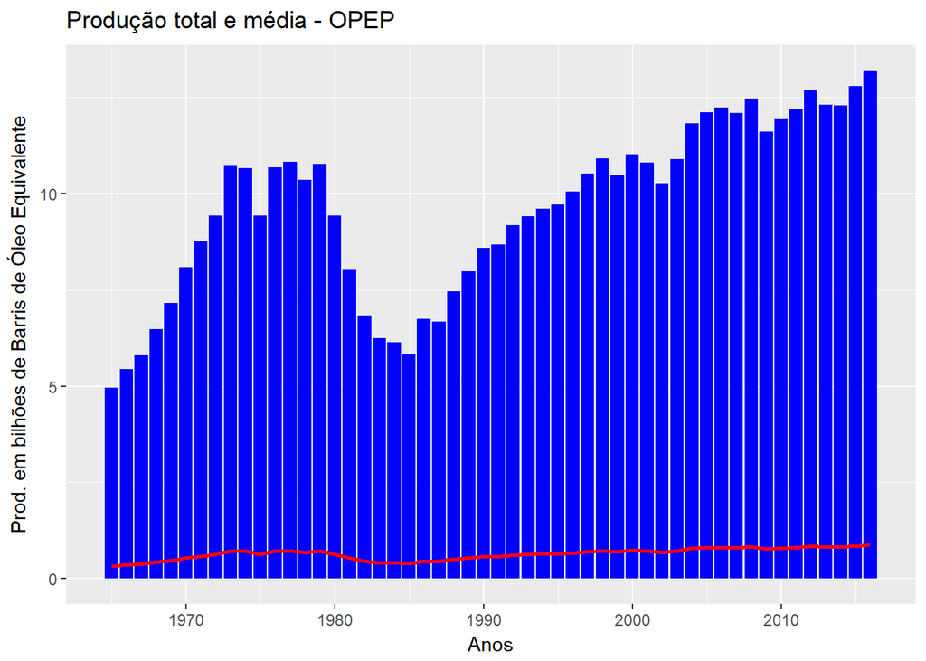

# Análise Multivariada

### Discuta sobre os relacionamentos observados nesta parte da investigação. Quais atributos que fortaleceram os demais na observação das variáveis de interesse?

Com a introdução da variável tempo (Anos), fica claro como que os aspectos históricos e geopolíticos influenciam os movimentos de produção e no consumo, destaco alguns pontos interessantes:

1. No gráfico “Consumo x Produção - Alguns Países”, fica claro a posição consolidada de importador líquido ou exportador líquido de alguns países, destacando o Brasil que está muito perto de ser declarado auto-suficiente, podendo se tornar um exportador líquido;
2. No gráfico “Comparativo Consumo x Produção - Alguns Países”, destaquei três movimentos interessantes: O crescimento exponencial do consumo da China, o impacto do Segundo Choque do Petróleo na Arábia Saudita (O maior produtor do mundo - **OPEP**) e por último o crescimento da produção após 2010 nos Estados Unidos com a introdução da exploração dos não convencionais;
3. O Segundo Choque do Petróleo (Destacado nos SLIDES sobre a **OPEP**) mostra uma queda expressiva na produção https://www1.folha.uol.com.br/folha/dinheiro/petroleo_choque2.shtml do países membros da **OPEP**.

Os dois últimos gráficos de produção dos países da **OPEP**, deixa evidente também, que apesar da alta produção, a média é baixa, pois somente alguns países da **OPEP** são super produtores (Gráfico de Barras e Gráfico de Caixas).

### Interações surpreendentes e/ou interessantes foram encontradas entre os atributos?

Como descrito, a variável tempo interage diretamente com as varáveis **Consumo** e **Produção**.

### OPCIONAL: Modelos foram criados usando este conjunto de dados? Discuta sobre os pontos fortes e as limitações do seu modelo.

# Gráficos Finais e Sumário

### Primeiro Gráfico

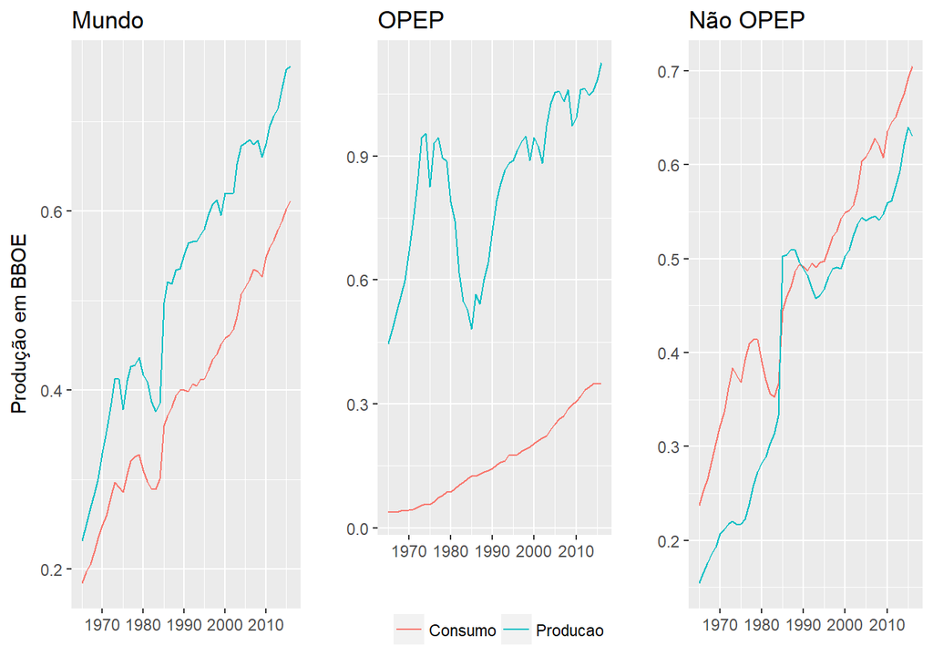

### Descrição do Primeiro Gráfico

Esse gráfico ilustra o Consumo e a Produção ao longo dos anos, fazendo a análise em 3 grupos distintos: Os países que não são membros da **OPEP**, os membros da **OPEP** e todos os países juntos. Chama a atenção como a produção dos países da **OPEP** é bem maior que o seu respectivo consumo. Fica claro também que é por conta dessa super-produção dos países da **OPEP** que não há falta de Petróleo em nível mundial pois é evidente que isolando os países não membros da **OPEP**, os mesmos têm consumo maior que as suas produções.

### Segundo Gráfico

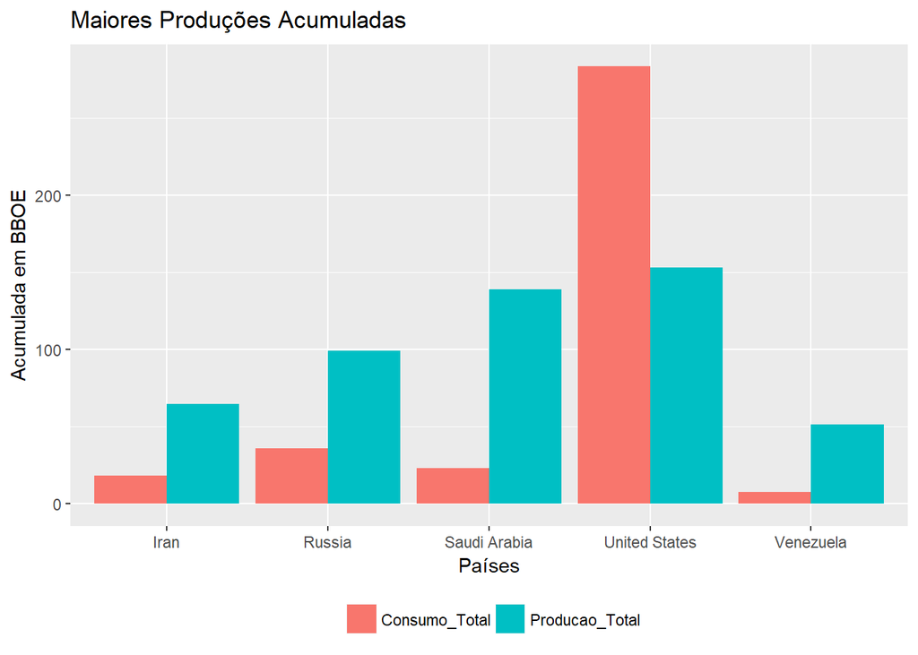

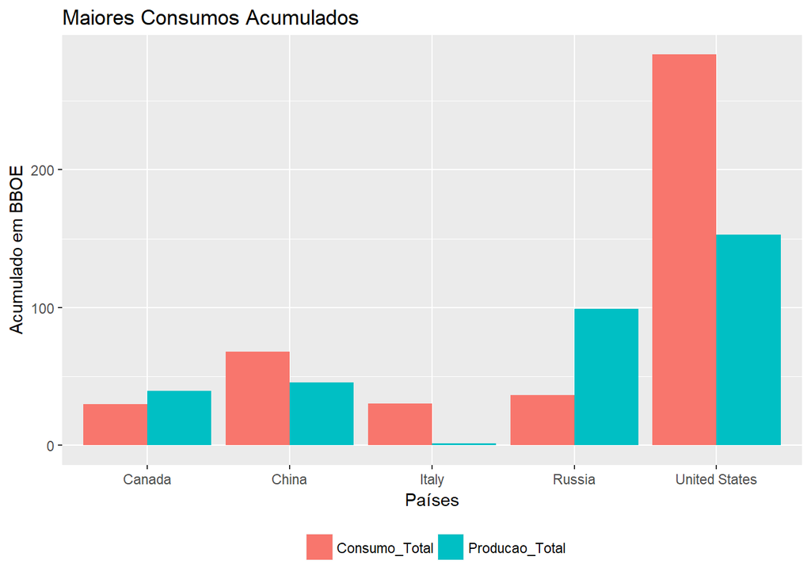

### Descrição do Segundo Gráfico

Esses dois gráficos ilustram os maiores consumidos e maiores produtores em valores acumulados ao longo dos anos.

### Terceiro Gráfico

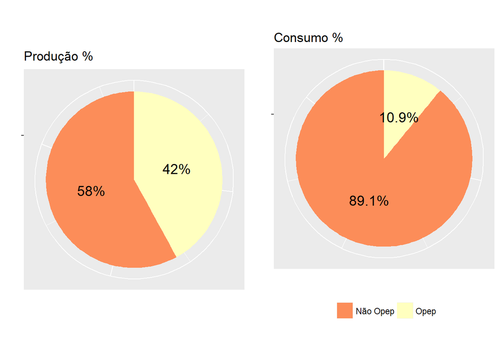

### Descrição do Terceiro Gráfico

Ilustrando consumo e prodção em termos percentuais, separando por países membros ou não da **OPEP**. Destaque para o consumo elevadíssimo dos países que não são da **OPEP**.

# Reflexão

A EDA explora como os aspectos geopolíticos e históricos influenciam o consumo e a produção de um dos principais commodities do mundo. A análise separou o grupo **OPEP**, que representa os países produtores de petróleo, e que tem um comportamento singular em relação a produção. Foi possível indentificar países importadores líquidos e países exportadores líquidos, foi ainda possível identificar e analisar quedas e crescimentos, causados por eventos específicos, como: O **segundo choque do petróleo**, a **exploração dos não convencionais** nos Estados Unidos e o **desenvolvimento econômico** da China.